# MH3510 Assignment 1

Neo Shun Xian Nicholas

24 September 2020

**Goal: To explore the relationship between the amount of beta-erythoidine in an aqueous solution and the colorimeter reading of the turbidity**

**X: Concentration (mg/mL)**  
**Y: Colorimeter Reading**

## Declaration of data

**Storing the data into vector X and Y for concentration and colorimeter reading respectively**

```r
X <- c(40,50,60,70,80,90,40,60,80,50)
Y <- c(69,175,272,335,490,415,72,265,492,180)
```

## a: Fit a simple regression to the data

**Fit linear model**

```r
slr <- lm(Y~X)
# Display basic information of this model
slr
```

```
##
## Call:
## lm(formula = Y ~ X)
##
## Coefficients:
## (Intercept)            X
##    -252.297        8.529
```

**Plot data and the best fit line**

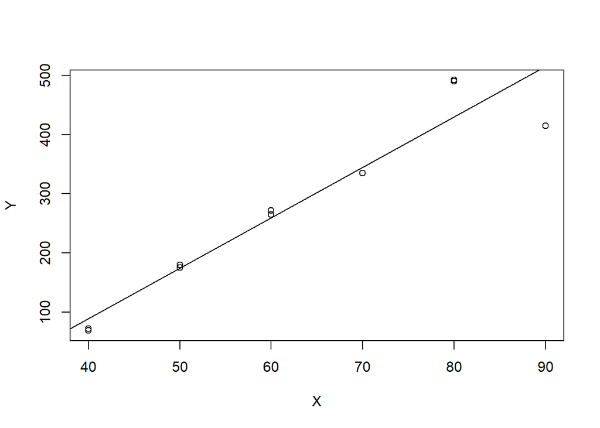

```r
# Plot data
plot(X,Y)
# Plot best fit line
abline(slr)
```

As shown in the above plot, it seems that the linear model of Y against X fits fairly well to the data, except with larger deviations of actual value of Y and and predicted value of Y when X equals to 80 and 90.

## b: Obtain the residuals and examine them

**Obtain and display the residual values**

```r
# Obtain residuals
residual <- slr$res
# display the residuals value
residual
```

```
##            1            2            3            4            5
##  -19.8623188    0.8478261   12.5579710   -9.7318841   59.9782609
##            6            7            8            9           10
## -100.3115942  -16.8623188    5.5579710   61.9782609    5.8478261
```

**Examining the residual values based on the output above**  
From the residual values, there are 3 points of predicted Y values that has significant deviations from the actual Y values with residual values -100.31, 59.978 and 61.978

## c: Comment on the adequacy of the model

**Examine the residuals by plotting**

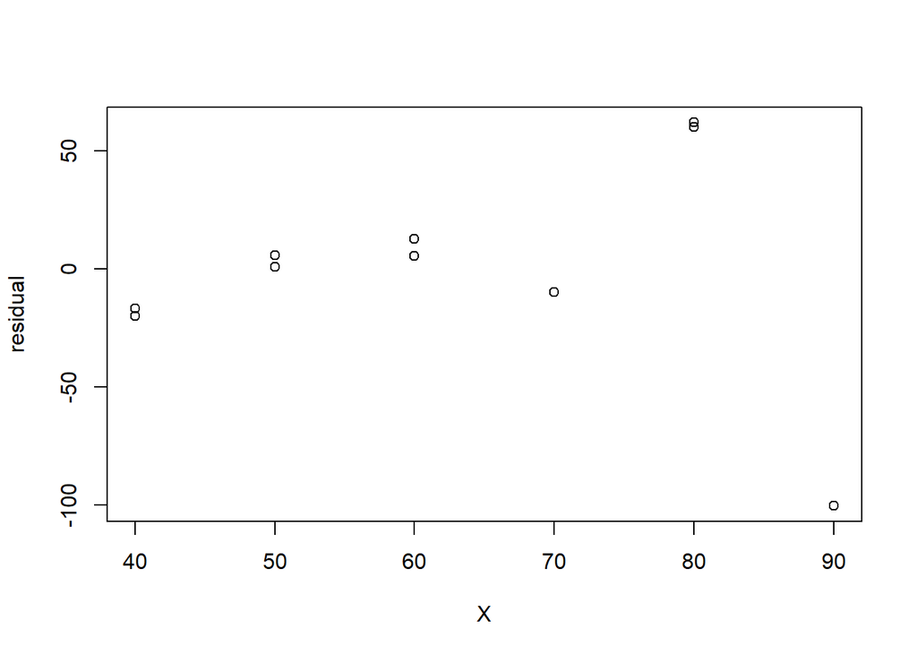

```r
# Plot residual against X plot
plot(X,residual)
```

**Comment**  
From the above plot, we can see that the plot between the residual and Concentration(X) is **not linear**. This implies that there is **no linear relationship** between the response and predicted variable (Y_actual vs Y_predicted). Hence, the model is **not adequate** to show the relationship between the Concentration(X) and Colorimeter Reading(Y). Moreover, as shown in the plot above, it seems to imply that a **higher order polynomial term such as x^2 should be fitted** in order to show the adequacy of the model, even without the abnormal behaviour of Y when X is 80 & 90.